# SI370 Winter 2018 -- Assignment 6

Due by: March 8 2:30pm.

Submission Instructions: Submit two files on Canvas:

1. A Jupyter Notebook file named HW-6-YOUR_UNIQUE_NAME.ipynb. Please observe the following requirements: This file should show all of the required work, including code, results, visualizations (if any), and necessary comments to your code. Irrelevant code and results should be deleted prior to submission.
2. An html file named HW-6-YOUR_UNIQUE_NAME.html showing the preview of the above IPython Notebook. To create this file, select File -> Download as HTML. We want this in case something breaks when we load your notebook. This will let us see what you saw when you were done.

**Please do NOT compress files. Before generating the html copy, please select Kernel -> Restart & Run All. This step guarantees all your output is consistent with your code. If you use your own data sets, please submit them with your assignment so we can run your notebook**

# Load everything up that we need

```python
import pandas as pd
import numpy as np
import seaborn as sns
from scipy import stats
import statsmodels.formula.api as smf
import statsmodels.api as sm
%matplotlib inline
import warnings
warnings.filterwarnings('ignore')
sns.set_context("notebook")  # make figures fit
from pylab import rcParams
import matplotlib.pyplot as plt
from statsmodels.graphics.mosaicplot import mosaic
from IPython.display import Image
from IPython.core.display import HTML
import sklearn as sk
import sklearn.cluster as skc
import sklearn.decomposition as skd
import sklearn.manifold as skm
import sklearn.preprocessing as skp

# make the Pandas tables a little more readable

from IPython.core.display import HTML
css = open('style-table.css').read() + open('style-notebook.css').read()
HTML('<style>{}</style>'.format(css))

def round_of_rating(number):
    return round(number * 2) / 2
```

# "Problem" 0: Reading

Urdan, Statistics in Plain English, Chapter 15, available in the "Additional Readings" folder on Canvas.

# Problem 1

Download and import movies-hw6.csv from Canvas. The imported DataFrame should contain 146 rows.

We will be conducting some analysis related to this article:

https://fivethirtyeight.com/features/fandango-movies-ratings/

Columns:

- film- The film in question
- RT- The Rotten Tomatoes Tomatometer score for the film
- RT_U- The Rotten Tomatoes user score for the film
- MT- The Metacritic critic score for the film
- MT_U- The Metacritic user score for the film
- IMDB- The IMDb user score for the film
- FD_Stars- The number of stars the film had on its Fandango movie page
- FD_Ratings- The Fandango ratingValue for the film, as pulled from the HTML of each page. This is the actual average score the movie obtained.
- Meta_user_vote_count- The number of user votes the film had on Metacritic
- IMDB_user_vote_count- The number of user votes the film had on IMDB
- FD_votes- The number of user votes the film had on Fandango
- runtime- Runtime (in minutes)
- rating- Rating (R/PG/etc.)
- genre1- first genre tag from IMDB
- genre2- second genre tag from IMDB
- genre3- third genre tag from IMDB
- imdb_id- IMDB id

**Note that IMDB metadata is noisy. Information may be missing or wrong.**

### Problem 1a) Load the data (2 points)

Load it into df_movies. Set the index to be the film name.

```python
df_movies = pd.read_csv('movies-hw6.csv')
df_movies.shape
df_movies.head()
```

|  | film | RT | RT_U | Meta | Meta_U | IMDB | FD_star | FD_rate | Meta_user_vote_count | IMDB_user_vote_count | FD_votes | runtime | rating | genre1 | genre2 | genre3 | imdb_id |
| --- | --- | --- | --- | --- | --- | --- | --- | --- | --- | --- | --- | --- | --- | --- | --- | --- | --- |
| 0 | Avengers: Age of Ultron (2015) | 74 | 86 | 66 | 7.1 | 7.8 | 5.0 | 4.5 | 1330 | 271107 | 14846 | 141.0 | PG-13 | Action | Adventure | Sci-Fi | tt2395427 |
| 1 | Cinderella (2015) | 85 | 80 | 67 | 7.5 | 7.1 | 5.0 | 4.5 | 249 | 65709 | 12640 | 105.0 | PG | Drama | Family | Fantasy | tt1661199 |
| 2 | Ant-Man (2015) | 80 | 90 | 64 | 8.1 | 7.8 | 5.0 | 4.5 | 627 | 103660 | 12055 | 117.0 | PG-13 | Action | Adventure | Comedy | tt0478970 |
| 3 | Do You Believe? (2015) | 18 | 84 | 22 | 4.7 | 5.4 | 5.0 | 4.5 | 31 | 3136 | 1793 | 120.0 | PG-13 | Drama | NaN | NaN | tt4056738 |
| 4 | Hot Tub Time Machine 2 (2015) | 14 | 28 | 29 | 3.4 | 5.1 | 3.5 | 3.0 | 88 | 19560 | 1021 | 93.0 | R | Comedy | Sci-Fi | NaN | tt2637294 |

### Problem 1b) Normalize the data (7 points)

The different rating schemes use different scores. Metacritic, for example, goes to 100, IMDB goes to 10, and Fandango gives up to 5 stars.

For each score (the 7 score columns), normalize the data so it ranges from 0 to 5 (basically to simulate the star scheme). Create a new column for each of the original columns and append "_norm" to it (e.g., RT should be RT_norm).

You should consider writing a loop here, you're going to want to do this multiple times

```python
N_Movies = df_movies.copy()

for row in N_Movies['RT']:
    N_Movies['RT_norm'] = (float(row/5)/5)
for row in N_Movies['RT_U']:
    N_Movies['RT_U_norm'] = (float(row/5)/5)
for row in N_Movies['Meta']:
    N_Movies['Meta_norm'] = (float(row/5)/5)
for row in N_Movies['Meta_U']:
    N_Movies['Meta_U_norm'] = float(row)/2
for row in N_Movies['IMDB']:
    N_Movies['IMDB_norm'] = float(row)/2
for row in N_Movies['FD_star']:
    N_Movies['FD_star_norm'] = float(row)
for row in N_Movies['FD_rate']:
    N_Movies['FD_rate_norm'] = float(row)
```

```python
N_Movies.head()
```

|  | film | RT | RT_U | Meta | Meta_U | IMDB | FD_star | FD_rate | Meta_user_vote_count | IMDB_user_vote_count | ... | genre2 | genre3 | imdb_id | RT_norm | RT_U_norm | Meta_norm | Meta_U_norm | IMDB_norm | FD_star_norm | FD_rate_norm |
| --- | --- | --- | --- | --- | --- | --- | --- | --- | --- | --- | --- | --- | --- | --- | --- | --- | --- | --- | --- | --- | --- |
| 0 | Avengers: Age of Ultron (2015) | 74 | 86 | 66 | 7.1 | 7.8 | 5.0 | 4.5 | 1330 | 271107 | ... | Adventure | Sci-Fi | tt2395427 | 3.48 | 2.52 | 2.72 | 3.2 | 3.35 | 3.5 | 3.5 |
| 1 | Cinderella (2015) | 85 | 80 | 67 | 7.5 | 7.1 | 5.0 | 4.5 | 249 | 65709 | ... | Family | Fantasy | tt1661199 | 3.48 | 2.52 | 2.72 | 3.2 | 3.35 | 3.5 | 3.5 |
| 2 | Ant-Man (2015) | 80 | 90 | 64 | 8.1 | 7.8 | 5.0 | 4.5 | 627 | 103660 | ... | Adventure | Comedy | tt0478970 | 3.48 | 2.52 | 2.72 | 3.2 | 3.35 | 3.5 | 3.5 |
| 3 | Do You Believe? (2015) | 18 | 84 | 22 | 4.7 | 5.4 | 5.0 | 4.5 | 31 | 3136 | ... | NaN | NaN | tt4056738 | 3.48 | 2.52 | 2.72 | 3.2 | 3.35 | 3.5 | 3.5 |
| 4 | Hot Tub Time Machine 2 (2015) | 14 | 28 | 29 | 3.4 | 5.1 | 3.5 | 3.0 | 88 | 19560 | ... | Sci-Fi | NaN | tt2637294 | 3.48 | 2.52 | 2.72 | 3.2 | 3.35 | 3.5 | 3.5 |

5 rows × 24 columns

### Problem 1c) Round the data (7 points)

You'll notice that in the figures in the 538 article, they round the values to half stars (0,.5,1,1.5, etc.)

Do the same for your data. Put the rounded stars for the 7 scores in columns with _norm_rnd appended to them (e.g., the original RT got transformed to RT_norm in 1b, and should be RT_norm_rnd after rounding)

```python
for row in N_Movies['RT_norm']:
    N_Movies['RT_norm_rnd'] = round_of_rating(row)
for row in N_Movies['RT_U_norm']:
    N_Movies['RT_U_norm_rnd'] = round_of_rating(row)
for row in N_Movies['Meta_norm']:
    N_Movies['Meta_norm_rnd'] = round_of_rating(row)
for row in N_Movies['Meta_U_norm']:
    N_Movies['Meta_U_norm_rnd'] = round_of_rating(row)
for row in N_Movies['IMDB_norm']:
    N_Movies['IMDB_norm_rnd'] = round_of_rating(row)
for row in N_Movies['FD_star_norm']:
    N_Movies['FD_star_norm_rnd'] = round_of_rating(row)
for row in N_Movies['FD_rate_norm']:
    N_Movies['FD_rate_norm_rnd'] = round_of_rating(row)
```

```python
N_Movies
```

|  | film | RT | RT_U | Meta | Meta_U | IMDB | FD_star | FD_rate | Meta_user_vote_count | IMDB_user_vote_count | ... | IMDB_norm | FD_star_norm | FD_rate_norm | RT_norm_rnd | RT_U_norm_rnd | Meta_norm_rnd | Meta_U_norm_rnd | IMDB_norm_rnd | FD_star_norm_rnd | FD_rate_norm_rnd |
| --- | --- | --- | --- | --- | --- | --- | --- | --- | --- | --- | --- | --- | --- | --- | --- | --- | --- | --- | --- | --- | --- |
| 0 | Avengers: Age of Ultron (2015) | 74 | 86 | 66 | 7.1 | 7.8 | 5.0 | 4.5 | 1330 | 271107 | ... | 3.35 | 3.5 | 3.5 | 3.5 | 2.5 | 2.5 | 3.0 | 3.5 | 3.5 | 3.5 |
| 1 | Cinderella (2015) | 85 | 80 | 67 | 7.5 | 7.1 | 5.0 | 4.5 | 249 | 65709 | ... | 3.35 | 3.5 | 3.5 | 3.5 | 2.5 | 2.5 | 3.0 | 3.5 | 3.5 | 3.5 |
| 2 | Ant-Man (2015) | 80 | 90 | 64 | 8.1 | 7.8 | 5.0 | 4.5 | 627 | 103660 | ... | 3.35 | 3.5 | 3.5 | 3.5 | 2.5 | 2.5 | 3.0 | 3.5 | 3.5 | 3.5 |
| 3 | Do You Believe? (2015) | 18 | 84 | 22 | 4.7 | 5.4 | 5.0 | 4.5 | 31 | 3136 | ... | 3.35 | 3.5 | 3.5 | 3.5 | 2.5 | 2.5 | 3.0 | 3.5 | 3.5 | 3.5 |
| 4 | Hot Tub Time Machine 2 (2015) | 14 | 28 | 29 | 3.4 | 5.1 | 3.5 | 3.0 | 88 | 19560 | ... | 3.35 | 3.5 | 3.5 | 3.5 | 2.5 | 2.5 | 3.0 | 3.5 | 3.5 | 3.5 |
| 5 | The Water Diviner (2015) | 63 | 62 | 50 | 6.8 | 7.2 | 4.5 | 4.0 | 34 | 39373 | ... | 3.35 | 3.5 | 3.5 | 3.5 | 2.5 | 2.5 | 3.0 | 3.5 | 3.5 | 3.5 |
| 6 | Irrational Man (2015) | 42 | 53 | 53 | 7.6 | 6.9 | 4.0 | 3.5 | 17 | 2680 | ... | 3.35 | 3.5 | 3.5 | 3.5 | 2.5 | 2.5 | 3.0 | 3.5 | 3.5 | 3.5 |
| 7 | Top Five (2014) | 86 | 64 | 81 | 6.8 | 6.5 | 4.0 | 3.5 | 124 | 16876 | ... | 3.35 | 3.5 | 3.5 | 3.5 | 2.5 | 2.5 | 3.0 | 3.5 | 3.5 | 3.5 |
| 8 | Shaun the Sheep Movie (2015) | 99 | 82 | 81 | 8.8 | 7.4 | 4.5 | 4.0 | 62 | 12227 | ... | 3.35 | 3.5 | 3.5 | 3.5 | 2.5 | 2.5 | 3.0 | 3.5 | 3.5 | 3.5 |
| 9 | Love & Mercy (2015) | 89 | 87 | 80 | 8.5 | 7.8 | 4.5 | 4.0 | 54 | 5367 | ... | 3.35 | 3.5 | 3.5 | 3.5 | 2.5 | 2.5 | 3.0 | 3.5 | 3.5 | 3.5 |
| 10 | Far From The Madding Crowd (2015) | 84 | 77 | 71 | 7.5 | 7.2 | 4.5 | 4.0 | 35 | 12129 | ... | 3.35 | 3.5 | 3.5 | 3.5 | 2.5 | 2.5 | 3.0 | 3.5 | 3.5 | 3.5 |
| 11 | Black Sea (2015) | 82 | 60 | 62 | 6.6 | 6.4 | 4.0 | 3.5 | 37 | 16547 | ... | 3.35 | 3.5 | 3.5 | 3.5 | 2.5 | 2.5 | 3.0 | 3.5 | 3.5 | 3.5 |
| 12 | Leviathan (2014) | 99 | 79 | 92 | 7.2 | 7.7 | 4.0 | 3.5 | 145 | 22521 | ... | 3.35 | 3.5 | 3.5 | 3.5 | 2.5 | 2.5 | 3.0 | 3.5 | 3.5 | 3.5 |
| 13 | Unbroken (2014) | 51 | 70 | 59 | 6.5 | 7.2 | 4.5 | 4.1 | 218 | 77518 | ... | 3.35 | 3.5 | 3.5 | 3.5 | 2.5 | 2.5 | 3.0 | 3.5 | 3.5 | 3.5 |
| 14 | The Imitation Game (2014) | 90 | 92 | 73 | 8.2 | 8.1 | 5.0 | 4.6 | 566 | 334164 | ... | 3.35 | 3.5 | 3.5 | 3.5 | 2.5 | 2.5 | 3.0 | 3.5 | 3.5 | 3.5 |
| 15 | Taken 3 (2015) | 9 | 46 | 26 | 4.6 | 6.1 | 4.5 | 4.1 | 240 | 104235 | ... | 3.35 | 3.5 | 3.5 | 3.5 | 2.5 | 2.5 | 3.0 | 3.5 | 3.5 | 3.5 |
| 16 | Ted 2 (2015) | 46 | 58 | 48 | 6.5 | 6.6 | 4.5 | 4.1 | 197 | 49102 | ... | 3.35 | 3.5 | 3.5 | 3.5 | 2.5 | 2.5 | 3.0 | 3.5 | 3.5 | 3.5 |
| 17 | Southpaw (2015) | 59 | 80 | 57 | 8.2 | 7.8 | 5.0 | 4.6 | 128 | 23561 | ... | 3.35 | 3.5 | 3.5 | 3.5 | 2.5 | 2.5 | 3.0 | 3.5 | 3.5 | 3.5 |
| 18 | Night at the Museum: Secret of the Tomb (2014) | 50 | 58 | 47 | 5.8 | 6.3 | 4.5 | 4.1 | 103 | 50291 | ... | 3.35 | 3.5 | 3.5 | 3.5 | 2.5 | 2.5 | 3.0 | 3.5 | 3.5 | 3.5 |
| 19 | Pixels (2015) | 17 | 54 | 27 | 5.3 | 5.6 | 4.5 | 4.1 | 246 | 19521 | ... | 3.35 | 3.5 | 3.5 | 3.5 | 2.5 | 2.5 | 3.0 | 3.5 | 3.5 | 3.5 |
| 20 | McFarland, USA (2015) | 79 | 89 | 60 | 7.2 | 7.5 | 5.0 | 4.6 | 59 | 13769 | ... | 3.35 | 3.5 | 3.5 | 3.5 | 2.5 | 2.5 | 3.0 | 3.5 | 3.5 | 3.5 |
| 21 | Insidious: Chapter 3 (2015) | 59 | 56 | 52 | 6.9 | 6.3 | 4.5 | 4.1 | 115 | 25134 | ... | 3.35 | 3.5 | 3.5 | 3.5 | 2.5 | 2.5 | 3.0 | 3.5 | 3.5 | 3.5 |
| 22 | The Man From U.N.C.L.E. (2015) | 68 | 80 | 55 | 7.9 | 7.6 | 4.5 | 4.1 | 144 | 22104 | ... | 3.35 | 3.5 | 3.5 | 3.5 | 2.5 | 2.5 | 3.0 | 3.5 | 3.5 | 3.5 |
| 23 | Run All Night (2015) | 60 | 59 | 59 | 7.3 | 6.6 | 4.5 | 4.1 | 141 | 50438 | ... | 3.35 | 3.5 | 3.5 | 3.5 | 2.5 | 2.5 | 3.0 | 3.5 | 3.5 | 3.5 |
| 24 | Trainwreck (2015) | 85 | 74 | 75 | 6.0 | 6.7 | 4.5 | 4.1 | 169 | 27380 | ... | 3.35 | 3.5 | 3.5 | 3.5 | 2.5 | 2.5 | 3.0 | 3.5 | 3.5 | 3.5 |
| 25 | Selma (2014) | 99 | 86 | 89 | 7.1 | 7.5 | 5.0 | 4.6 | 316 | 45344 | ... | 3.35 | 3.5 | 3.5 | 3.5 | 2.5 | 2.5 | 3.0 | 3.5 | 3.5 | 3.5 |
| 26 | Ex Machina (2015) | 92 | 86 | 78 | 7.9 | 7.7 | 4.5 | 4.1 | 672 | 154499 | ... | 3.35 | 3.5 | 3.5 | 3.5 | 2.5 | 2.5 | 3.0 | 3.5 | 3.5 | 3.5 |
| 27 | Still Alice (2015) | 88 | 85 | 72 | 7.8 | 7.5 | 4.5 | 4.1 | 153 | 57123 | ... | 3.35 | 3.5 | 3.5 | 3.5 | 2.5 | 2.5 | 3.0 | 3.5 | 3.5 | 3.5 |
| 28 | Wild Tales (2014) | 96 | 92 | 77 | 8.8 | 8.2 | 4.5 | 4.1 | 107 | 50285 | ... | 3.35 | 3.5 | 3.5 | 3.5 | 2.5 | 2.5 | 3.0 | 3.5 | 3.5 | 3.5 |
| 29 | The End of the Tour (2015) | 92 | 89 | 84 | 7.5 | 7.9 | 4.5 | 4.1 | 19 | 1320 | ... | 3.35 | 3.5 | 3.5 | 3.5 | 2.5 | 2.5 | 3.0 | 3.5 | 3.5 | 3.5 |
| ... | ... | ... | ... | ... | ... | ... | ... | ... | ... | ... | ... | ... | ... | ... | ... | ... | ... | ... | ... | ... | ... |
| 116 | Clouds of Sils Maria (2015) | 89 | 67 | 78 | 7.1 | 6.8 | 3.5 | 3.4 | 36 | 11392 | ... | 3.35 | 3.5 | 3.5 | 3.5 | 2.5 | 2.5 | 3.0 | 3.5 | 3.5 | 3.5 |
| 117 | Testament of Youth (2015) | 81 | 79 | 77 | 7.9 | 7.3 | 4.0 | 3.9 | 15 | 5495 | ... | 3.35 | 3.5 | 3.5 | 3.5 | 2.5 | 2.5 | 3.0 | 3.5 | 3.5 | 3.5 |
| 118 | Infinitely Polar Bear (2015) | 80 | 76 | 64 | 7.9 | 7.2 | 4.0 | 3.9 | 8 | 1062 | ... | 3.35 | 3.5 | 3.5 | 3.5 | 2.5 | 2.5 | 3.0 | 3.5 | 3.5 | 3.5 |
| 119 | Phoenix (2015) | 99 | 81 | 91 | 8.0 | 7.2 | 3.5 | 3.4 | 21 | 3687 | ... | 3.35 | 3.5 | 3.5 | 3.5 | 2.5 | 2.5 | 3.0 | 3.5 | 3.5 | 3.5 |
| 120 | The Wolfpack (2015) | 84 | 73 | 75 | 7.0 | 7.1 | 3.5 | 3.4 | 8 | 1488 | ... | 3.35 | 3.5 | 3.5 | 3.5 | 2.5 | 2.5 | 3.0 | 3.5 | 3.5 | 3.5 |
| 121 | The Stanford Prison Experiment (2015) | 84 | 87 | 68 | 8.5 | 7.1 | 4.0 | 3.9 | 6 | 950 | ... | 3.35 | 3.5 | 3.5 | 3.5 | 2.5 | 2.5 | 3.0 | 3.5 | 3.5 | 3.5 |
| 122 | Tangerine (2015) | 95 | 86 | 86 | 7.3 | 7.4 | 4.0 | 3.9 | 14 | 696 | ... | 3.35 | 3.5 | 3.5 | 3.5 | 2.5 | 2.5 | 3.0 | 3.5 | 3.5 | 3.5 |
| 123 | Magic Mike XXL (2015) | 62 | 64 | 60 | 5.4 | 6.3 | 4.5 | 4.4 | 52 | 11937 | ... | 3.35 | 3.5 | 3.5 | 3.5 | 2.5 | 2.5 | 3.0 | 3.5 | 3.5 | 3.5 |
| 124 | Home (2015) | 45 | 65 | 55 | 7.3 | 6.7 | 4.5 | 4.4 | 177 | 41158 | ... | 3.35 | 3.5 | 3.5 | 3.5 | 2.5 | 2.5 | 3.0 | 3.5 | 3.5 | 3.5 |
| 125 | The Wedding Ringer (2015) | 27 | 66 | 35 | 3.3 | 6.7 | 4.5 | 4.4 | 126 | 37292 | ... | 3.35 | 3.5 | 3.5 | 3.5 | 2.5 | 2.5 | 3.0 | 3.5 | 3.5 | 3.5 |
| 126 | Woman in Gold (2015) | 52 | 81 | 51 | 7.2 | 7.4 | 4.5 | 4.4 | 72 | 17957 | ... | 3.35 | 3.5 | 3.5 | 3.5 | 2.5 | 2.5 | 3.0 | 3.5 | 3.5 | 3.5 |
| 127 | The Last Five Years (2015) | 60 | 60 | 60 | 6.9 | 6.0 | 4.5 | 4.4 | 20 | 4110 | ... | 3.35 | 3.5 | 3.5 | 3.5 | 2.5 | 2.5 | 3.0 | 3.5 | 3.5 | 3.5 |
| 128 | Mission: Impossible - Rogue Nation (2015) | 92 | 90 | 75 | 8.0 | 7.8 | 4.5 | 4.4 | 362 | 82579 | ... | 3.35 | 3.5 | 3.5 | 3.5 | 2.5 | 2.5 | 3.0 | 3.5 | 3.5 | 3.5 |
| 129 | Amy (2015) | 97 | 91 | 85 | 8.8 | 8.0 | 4.5 | 4.4 | 60 | 5630 | ... | 3.35 | 3.5 | 3.5 | 3.5 | 2.5 | 2.5 | 3.0 | 3.5 | 3.5 | 3.5 |
| 130 | Jurassic World (2015) | 71 | 81 | 59 | 7.0 | 7.3 | 4.5 | 4.5 | 1281 | 241807 | ... | 3.35 | 3.5 | 3.5 | 3.5 | 2.5 | 2.5 | 3.0 | 3.5 | 3.5 | 3.5 |
| 131 | Minions (2015) | 54 | 52 | 56 | 5.7 | 6.7 | 4.0 | 4.0 | 204 | 55895 | ... | 3.35 | 3.5 | 3.5 | 3.5 | 2.5 | 2.5 | 3.0 | 3.5 | 3.5 | 3.5 |
| 132 | Max (2015) | 35 | 73 | 47 | 5.9 | 7.0 | 4.5 | 4.5 | 15 | 5444 | ... | 3.35 | 3.5 | 3.5 | 3.5 | 2.5 | 2.5 | 3.0 | 3.5 | 3.5 | 3.5 |
| 133 | Paul Blart: Mall Cop 2 (2015) | 5 | 36 | 13 | 2.4 | 4.3 | 3.5 | 3.5 | 211 | 15004 | ... | 3.35 | 3.5 | 3.5 | 3.5 | 2.5 | 2.5 | 3.0 | 3.5 | 3.5 | 3.5 |
| 134 | The Longest Ride (2015) | 31 | 73 | 33 | 4.8 | 7.2 | 4.5 | 4.5 | 49 | 25214 | ... | 3.35 | 3.5 | 3.5 | 3.5 | 2.5 | 2.5 | 3.0 | 3.5 | 3.5 | 3.5 |
| 135 | The Lazarus Effect (2015) | 14 | 23 | 31 | 4.9 | 5.2 | 3.0 | 3.0 | 62 | 17691 | ... | 3.35 | 3.5 | 3.5 | 3.5 | 2.5 | 2.5 | 3.0 | 3.5 | 3.5 | 3.5 |
| 136 | The Woman In Black 2 Angel of Death (2015) | 22 | 25 | 42 | 4.4 | 4.9 | 3.0 | 3.0 | 55 | 14873 | ... | 3.35 | 3.5 | 3.5 | 3.5 | 2.5 | 2.5 | 3.0 | 3.5 | 3.5 | 3.5 |
| 137 | Danny Collins (2015) | 77 | 75 | 58 | 7.1 | 7.1 | 4.0 | 4.0 | 33 | 11206 | ... | 3.35 | 3.5 | 3.5 | 3.5 | 2.5 | 2.5 | 3.0 | 3.5 | 3.5 | 3.5 |
| 138 | Spare Parts (2015) | 52 | 83 | 50 | 7.1 | 7.2 | 4.5 | 4.5 | 7 | 47377 | ... | 3.35 | 3.5 | 3.5 | 3.5 | 2.5 | 2.5 | 3.0 | 3.5 | 3.5 | 3.5 |
| 139 | Serena (2015) | 18 | 25 | 36 | 5.3 | 5.4 | 3.0 | 3.0 | 19 | 12165 | ... | 3.35 | 3.5 | 3.5 | 3.5 | 2.5 | 2.5 | 3.0 | 3.5 | 3.5 | 3.5 |
| 140 | Inside Out (2015) | 98 | 90 | 94 | 8.9 | 8.6 | 4.5 | 4.5 | 807 | 96252 | ... | 3.35 | 3.5 | 3.5 | 3.5 | 2.5 | 2.5 | 3.0 | 3.5 | 3.5 | 3.5 |
| 141 | Mr. Holmes (2015) | 87 | 78 | 67 | 7.9 | 7.4 | 4.0 | 4.0 | 33 | 7367 | ... | 3.35 | 3.5 | 3.5 | 3.5 | 2.5 | 2.5 | 3.0 | 3.5 | 3.5 | 3.5 |
| 142 | '71 (2015) | 97 | 82 | 83 | 7.5 | 7.2 | 3.5 | 3.5 | 60 | 24116 | ... | 3.35 | 3.5 | 3.5 | 3.5 | 2.5 | 2.5 | 3.0 | 3.5 | 3.5 | 3.5 |
| 143 | Two Days, One Night (2014) | 97 | 78 | 89 | 8.8 | 7.4 | 3.5 | 3.5 | 123 | 24345 | ... | 3.35 | 3.5 | 3.5 | 3.5 | 2.5 | 2.5 | 3.0 | 3.5 | 3.5 | 3.5 |
| 144 | Gett: The Trial of Viviane Amsalem (2015) | 100 | 81 | 90 | 7.3 | 7.8 | 3.5 | 3.5 | 19 | 1955 | ... | 3.35 | 3.5 | 3.5 | 3.5 | 2.5 | 2.5 | 3.0 | 3.5 | 3.5 | 3.5 |
| 145 | Kumiko, The Treasure Hunter (2015) | 87 | 63 | 68 | 6.4 | 6.7 | 3.5 | 3.5 | 19 | 5289 | ... | 3.35 | 3.5 | 3.5 | 3.5 | 2.5 | 2.5 | 3.0 | 3.5 | 3.5 | 3.5 |

146 rows × 31 columns

# Problem 2

### Problem 2a) Bivariate analysis (7 points)

Compare the various scores to each other using a SPLOM. Try this with the original raw scores and the rounded ones. You'll find that correlations are easier to see with one over the other. Find the pair of scores that seem to have the WORST correlation.

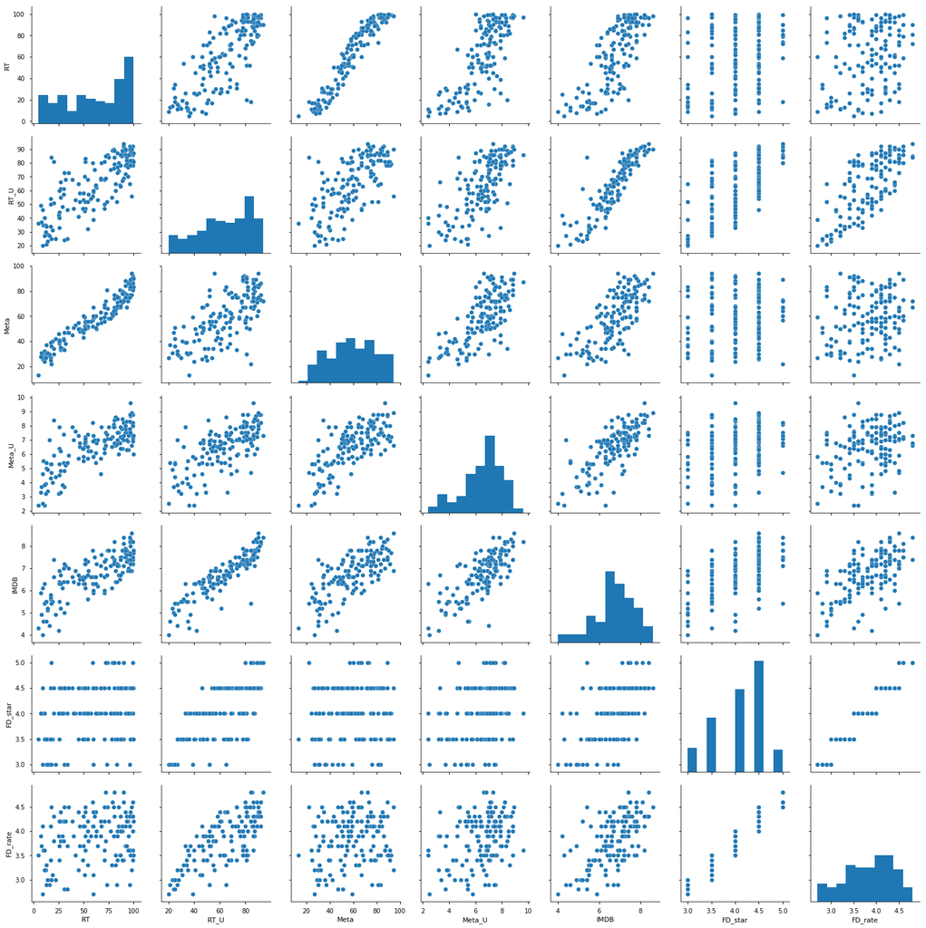

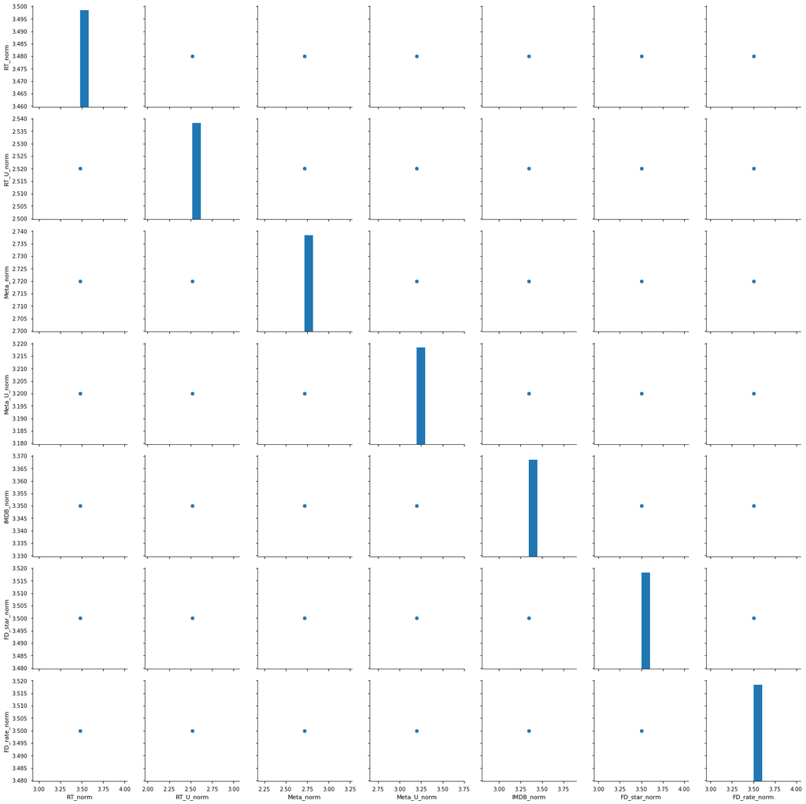

```python
sns.pairplot(N_Movies.loc[:, 'RT':'FD_rate'],size=3);
sns.pairplot(N_Movies.loc[:, 'RT_norm':'FD_rate_norm'],size=3);
# FD_rate and RT LOOK like they have the WORST correlation to me at first glance.
```

### Problem 2b) Generate a heatmap of the correlations (7 points)

Calculate the pairwise correlations between the seven scores, generate a heatmap. Confirm your guess above for worst correlation. What is the best correlation?

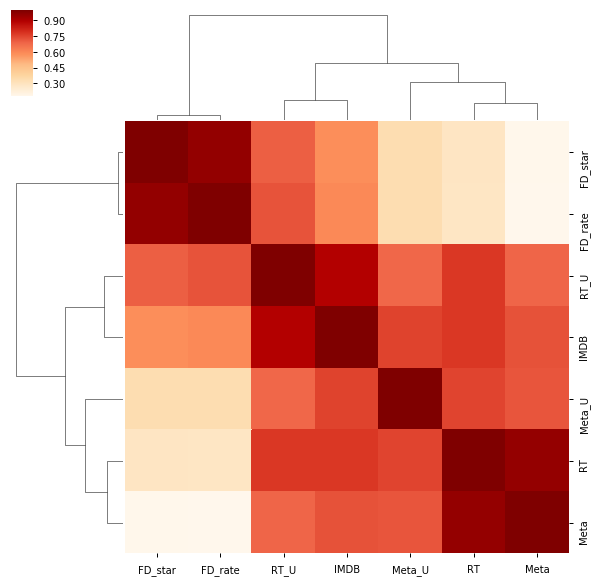

```python
sns.clustermap(N_Movies.loc[:, 'RT':'FD_rate'].corr(),cmap=plt.cm.OrRd)
```

## My guess from above was wrong. It looks like 'Meta' and FD_star or FD_rate have the worst correlation.

## The best correlation is between FD_star and FD_rate.

# Problem 3

### Problem 3a) Normalize (7 points)

Create a z-score normalized version of your df_movies table. Call this df_norm. You can keep the same column names as before

```python
df_norm = df_movies.copy()
df_norm['RT'] = skp.scale(df_norm['RT'].astype(np.float))
df_norm['RT_U'] = skp.scale(df_norm['RT_U'].astype(np.float))
df_norm['Meta'] = skp.scale(df_norm['Meta'].astype(np.float))
df_norm['Meta_U'] = skp.scale(df_norm['Meta_U'].astype(np.float))
df_norm['IMDB'] = skp.scale(df_norm['IMDB'].astype(np.float))
df_norm['FD_star'] = skp.scale(df_norm['FD_star'].astype(np.float))
df_norm['FD_rate'] = skp.scale(df_norm['FD_rate'].astype(np.float))
df_norm.head()
```

|  | film | RT | RT_U | Meta | Meta_U | IMDB | FD_star | FD_rate | Meta_user_vote_count | IMDB_user_vote_count | FD_votes | runtime | rating | genre1 | genre2 | genre3 | imdb_id |
| --- | --- | --- | --- | --- | --- | --- | --- | --- | --- | --- | --- | --- | --- | --- | --- | --- | --- |
| 0 | Avengers: Age of Ultron (2015) | 0.437404 | 1.108618 | 0.369749 | 0.385793 | 1.112583 | 1.691559 | 1.306699 | 1330 | 271107 | 14846 | 141.0 | PG-13 | Action | Adventure | Sci-Fi | tt2395427 |
| 1 | Cinderella (2015) | 0.803274 | 0.807953 | 0.421162 | 0.651480 | 0.379941 | 1.691559 | 1.306699 | 249 | 65709 | 12640 | 105.0 | PG | Drama | Family | Fantasy | tt1661199 |
| 2 | Ant-Man (2015) | 0.636970 | 1.309062 | 0.266924 | 1.050011 | 1.112583 | 1.691559 | 1.306699 | 627 | 103660 | 12055 | 117.0 | PG-13 | Action | Adventure | Comedy | tt0478970 |
| 3 | Do You Believe? (2015) | -1.425208 | 1.008396 | -1.892411 | -1.208331 | -1.399331 | 1.691559 | 1.306699 | 31 | 3136 | 1793 | 120.0 | PG-13 | Drama | NaN | NaN | tt4056738 |
| 4 | Hot Tub Time Machine 2 (2015) | -1.558252 | -1.797815 | -1.532522 | -2.071815 | -1.713320 | -1.093790 | -1.686680 | 88 | 19560 | 1021 | 93.0 | R | Comedy | Sci-Fi | NaN | tt2637294 |

### Problem 3b) PCA (7 points)

Build the PCA model for the df_norm table above.

```python
df_norm.set_index('film', inplace=True)


#pca_model = skd.PCA().fit(df_norm)
```

```python
df_ratings = df_norm.loc[:, 'RT':'FD_rate']
```

```python
df_ratings
```

| film | RT | RT_U | Meta | Meta_U | IMDB | FD_star | FD_rate |
| --- | --- | --- | --- | --- | --- | --- | --- |
| Avengers: Age of Ultron (2015) | 0.437404 | 1.108618 | 0.369749 | 0.385793 | 1.112583 | 1.691559 | 1.306699 |
| Cinderella (2015) | 0.803274 | 0.807953 | 0.421162 | 0.651480 | 0.379941 | 1.691559 | 1.306699 |
| Ant-Man (2015) | 0.636970 | 1.309062 | 0.266924 | 1.050011 | 1.112583 | 1.691559 | 1.306699 |
| Do You Believe? (2015) | -1.425208 | 1.008396 | -1.892411 | -1.208331 | -1.399331 | 1.691559 | 1.306699 |
| Hot Tub Time Machine 2 (2015) | -1.558252 | -1.797815 | -1.532522 | -2.071815 | -1.713320 | -1.093790 | -1.686680 |
| The Water Diviner (2015) | 0.071534 | -0.094044 | -0.452855 | 0.186527 | 0.484604 | 0.763109 | 0.308906 |
| Irrational Man (2015) | -0.626946 | -0.545042 | -0.298616 | 0.717902 | 0.170615 | -0.165340 | -0.688887 |
| Top Five (2014) | 0.836535 | 0.006178 | 1.140940 | 0.186527 | -0.248037 | -0.165340 | -0.688887 |
| Shaun the Sheep Movie (2015) | 1.268927 | 0.908174 | 1.140940 | 1.514963 | 0.693931 | 0.763109 | 0.308906 |
| Love & Mercy (2015) | 0.936318 | 1.158729 | 1.089527 | 1.315698 | 1.112583 | 0.763109 | 0.308906 |
| Far From The Madding Crowd (2015) | 0.770013 | 0.657620 | 0.626813 | 0.651480 | 0.484604 | 0.763109 | 0.308906 |
| Black Sea (2015) | 0.703491 | -0.194266 | 0.164098 | 0.053683 | -0.352700 | -0.165340 | -0.688887 |
| Leviathan (2014) | 1.268927 | 0.757842 | 1.706480 | 0.452214 | 1.007920 | -0.165340 | -0.688887 |
| Unbroken (2014) | -0.327597 | 0.306843 | 0.009860 | -0.012738 | 0.484604 | 0.763109 | 0.508464 |
| The Imitation Game (2014) | 0.969579 | 1.409283 | 0.729638 | 1.116433 | 1.426572 | 1.691559 | 1.506257 |
| Taken 3 (2015) | -1.724556 | -0.895818 | -1.686760 | -1.274753 | -0.666689 | 0.763109 | 0.508464 |
| Ted 2 (2015) | -0.493902 | -0.294487 | -0.555680 | -0.012738 | -0.143374 | 0.763109 | 0.508464 |
| Southpaw (2015) | -0.061510 | 0.807953 | -0.092965 | 1.116433 | 1.112583 | 1.691559 | 1.506257 |
| Night at the Museum: Secret of the Tomb (2014) | -0.360858 | -0.294487 | -0.607093 | -0.477691 | -0.457363 | 0.763109 | 0.508464 |
| Pixels (2015) | -1.458469 | -0.494931 | -1.635348 | -0.809800 | -1.190005 | 0.763109 | 0.508464 |
| McFarland, USA (2015) | 0.603709 | 1.258951 | 0.061273 | 0.452214 | 0.798594 | 1.691559 | 1.506257 |
| Insidious: Chapter 3 (2015) | -0.061510 | -0.394709 | -0.350029 | 0.252949 | -0.457363 | 0.763109 | 0.508464 |
| The Man From U.N.C.L.E. (2015) | 0.237838 | 0.807953 | -0.195791 | 0.917167 | 0.903257 | 0.763109 | 0.508464 |
| Run All Night (2015) | -0.028249 | -0.244376 | 0.009860 | 0.518636 | -0.143374 | 0.763109 | 0.508464 |
| Trainwreck (2015) | 0.803274 | 0.507287 | 0.832464 | -0.344848 | -0.038711 | 0.763109 | 0.508464 |
| Selma (2014) | 1.268927 | 1.108618 | 1.552242 | 0.385793 | 0.798594 | 1.691559 | 1.506257 |
| Ex Machina (2015) | 1.036101 | 1.108618 | 0.986702 | 0.917167 | 1.007920 | 0.763109 | 0.508464 |
| Still Alice (2015) | 0.903057 | 1.058507 | 0.678226 | 0.850745 | 0.798594 | 0.763109 | 0.508464 |
| Wild Tales (2014) | 1.169145 | 1.409283 | 0.935289 | 1.514963 | 1.531235 | 0.763109 | 0.508464 |
| The End of the Tour (2015) | 1.036101 | 1.258951 | 1.295178 | 0.651480 | 1.217246 | 0.763109 | 0.508464 |
| ... | ... | ... | ... | ... | ... | ... | ... |
| Clouds of Sils Maria (2015) | 0.936318 | 0.156511 | 0.986702 | 0.385793 | 0.065952 | -1.093790 | -0.888446 |
| Testament of Youth (2015) | 0.670231 | 0.757842 | 0.935289 | 0.917167 | 0.589267 | -0.165340 | 0.109347 |
| Infinitely Polar Bear (2015) | 0.636970 | 0.607509 | 0.266924 | 0.917167 | 0.484604 | -0.165340 | 0.109347 |
| Phoenix (2015) | 1.268927 | 0.858063 | 1.655067 | 0.983589 | 0.484604 | -1.093790 | -0.888446 |
| The Wolfpack (2015) | 0.770013 | 0.457176 | 0.832464 | 0.319371 | 0.379941 | -1.093790 | -0.888446 |
| The Stanford Prison Experiment (2015) | 0.770013 | 1.158729 | 0.472575 | 1.315698 | 0.379941 | -0.165340 | 0.109347 |
| Tangerine (2015) | 1.135884 | 1.108618 | 1.398004 | 0.518636 | 0.693931 | -0.165340 | 0.109347 |
| Magic Mike XXL (2015) | 0.038273 | 0.006178 | 0.061273 | -0.743378 | -0.457363 | 0.763109 | 1.107140 |
| Home (2015) | -0.527163 | 0.056289 | -0.195791 | 0.518636 | -0.038711 | 0.763109 | 1.107140 |
| The Wedding Ringer (2015) | -1.125860 | 0.106400 | -1.224046 | -2.138237 | -0.038711 | 0.763109 | 1.107140 |
| Woman in Gold (2015) | -0.294336 | 0.858063 | -0.401442 | 0.452214 | 0.693931 | 0.763109 | 1.107140 |
| The Last Five Years (2015) | -0.028249 | -0.194266 | 0.061273 | 0.252949 | -0.771353 | 0.763109 | 1.107140 |
| Mission: Impossible - Rogue Nation (2015) | 1.036101 | 1.309062 | 0.832464 | 0.983589 | 1.112583 | 0.763109 | 1.107140 |
| Amy (2015) | 1.202405 | 1.359173 | 1.346591 | 1.514963 | 1.321909 | 0.763109 | 1.107140 |
| Jurassic World (2015) | 0.337621 | 0.858063 | 0.009860 | 0.319371 | 0.589267 | 0.763109 | 1.306699 |
| Minions (2015) | -0.227815 | -0.595153 | -0.144378 | -0.544113 | -0.038711 | -0.165340 | 0.308906 |
| Max (2015) | -0.859772 | 0.457176 | -0.607093 | -0.411269 | 0.275278 | 0.763109 | 1.306699 |
| Paul Blart: Mall Cop 2 (2015) | -1.857600 | -1.396927 | -2.355126 | -2.736033 | -2.550625 | -1.093790 | -0.688887 |
| The Longest Ride (2015) | -0.992816 | 0.457176 | -1.326871 | -1.141909 | 0.484604 | 0.763109 | 1.306699 |
| The Lazarus Effect (2015) | -1.558252 | -2.048369 | -1.429697 | -1.075488 | -1.608657 | -2.022240 | -1.686680 |
| The Woman In Black 2 Angel of Death (2015) | -1.292164 | -1.948147 | -0.864157 | -1.407597 | -1.922646 | -2.022240 | -1.686680 |
| Danny Collins (2015) | 0.537187 | 0.557398 | -0.041553 | 0.385793 | 0.379941 | -0.165340 | 0.308906 |
| Spare Parts (2015) | -0.294336 | 0.958285 | -0.452855 | 0.385793 | 0.484604 | 0.763109 | 1.306699 |
| Serena (2015) | -1.425208 | -1.948147 | -1.172633 | -0.809800 | -1.399331 | -2.022240 | -1.686680 |
| Inside Out (2015) | 1.235666 | 1.309062 | 1.809306 | 1.581385 | 1.949887 | 0.763109 | 1.306699 |
| Mr. Holmes (2015) | 0.869796 | 0.707731 | 0.421162 | 0.917167 | 0.693931 | -0.165340 | 0.308906 |
| '71 (2015) | 1.202405 | 0.908174 | 1.243766 | 0.651480 | 0.484604 | -1.093790 | -0.688887 |
| Two Days, One Night (2014) | 1.202405 | 0.707731 | 1.552242 | 1.514963 | 0.693931 | -1.093790 | -0.688887 |
| Gett: The Trial of Viviane Amsalem (2015) | 1.302188 | 0.858063 | 1.603655 | 0.518636 | 1.112583 | -1.093790 | -0.688887 |
| Kumiko, The Treasure Hunter (2015) | 0.869796 | -0.043933 | 0.472575 | -0.079160 | -0.038711 | -1.093790 | -0.688887 |

146 rows × 7 columns

```python
df_ratings['RT_U'].argmin()
```

```
'Fantastic Four (2015)'
```

```python
pca_model = skd.PCA().fit(df_ratings)
```

```python
pca_model.components_.shape
```

```
(7, 7)
```

```python
pca_model.explained_variance_
```

```
array([ 4.79609002,  1.60628127,  0.32681175,  0.16915035,  0.08136711,
        0.03885255,  0.02972281])
```

### Problem 3c) Genrate a scree plot (7 points)

Based on the data, how many principle components do you think you need? Why?

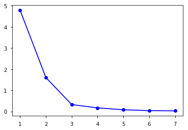

```python
plt.plot(range(1,8),pca_model.explained_variance_,'b-o')
```